# Persons-Activity

Niranjan Agnihotri

July 29, 2017

## Introduction

This project focuses on using the HAR data set to predict the quality of actions performed by the people base on the sensor data. First we download the data set from the sourses and start cleaning it.

## Data Processing

```r
if(!file.exists('pml-training.csv')) {
  download.file(url = 'https://d396qusza40orc.cloudfront.net/predmachlearn/pml-training.csv',
                destfile = 'pml-training.csv')
}
if(!file.exists('pml-testing.csv')) {
  download.file(url = 'https://d396qusza40orc.cloudfront.net/predmachlearn/pml-testing.csv',
                destfile = 'pml-testing.csv')
}

training <- read.csv(file = 'pml-training.csv')
testing <- read.csv(file = 'pml-testing.csv')
```

As there are large number of features, we investigate whether all of them are useful. So we check for various properties of features and eliminate the extraneous of them. First we check for NAs.

```r
# Removing Columns have high NA values
nas <- sapply(X = training, FUN = function(x) {print(mean(is.na(x))*100)})
```

```r
print(table(nas))
```

```
## nas
##                0 97.9308938946081
##               93               67
```

From the above table we see that there is a pattern in the occurence of missing values. There are around 67 variables with NAs. We drop them straight away.

```r
# Thus we remove 67 variables straightaway from training and test sets.
nas <- nas[nas>0]
na_attr <- names(nas)

# Removing variable 'X'
na_attr <- append(na_attr, c('X', 'user_name'))

training <- training[, !(names(training) %in% na_attr)]
testing <- testing[, !(names(testing) %in% na_attr)]

#Deleting the near zero predictors
nzv <- nearZeroVar(training[,-92], saveMetrics = FALSE, names = TRUE)

training <- training[, !(names(training) %in% nzv)]
testing <- testing[, !(names(testing) %in% nzv)]


#dplyr
train1 <- tbl_df(training)
test1 <- tbl_df(testing)

#Getting rid of timestamps as of now
train1 <- train1[,-c(1:3)]
test1 <- test1[,-c(1:3)]
```

Now, we eliminate the NearToZero variables. This will eliminate the variables that have very low variance. These variables contain very less information so we directly eliminate them. Now, we find the, co relation between all the pairs of remaining variables. This, will give us insights about which variables are tightly corelated. If large number of variables are largely related that we eliminate one of the corelated pair.

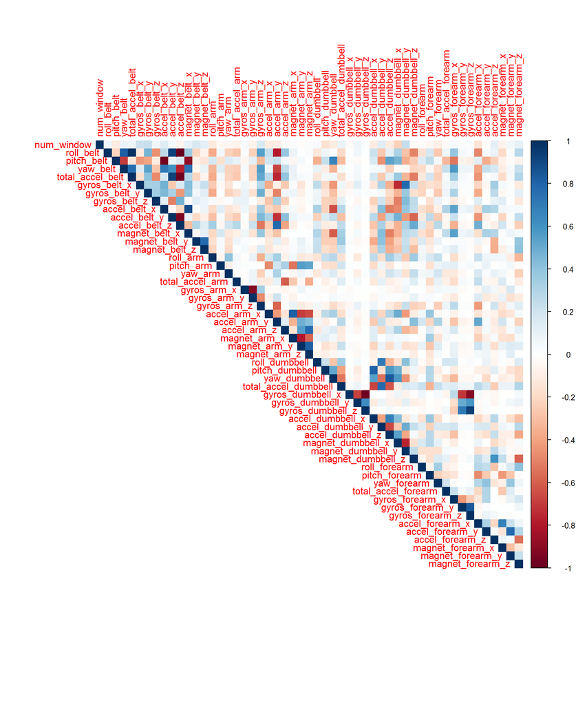

```r
#co relation plot
cor <- cor(train1[,-54])
corrplot(cor, method = "color", type = "upper")
```

```r
#Comments on correlation
```

There are only a couple of variables who are strongly co related so, I don’t intend to drop them as they are very few, rest the data set is ok.

```r
# creating partition of training set for validation afterwards.
inTrain <- createDataPartition(train1$classe, p = .90, list = FALSE)
train <- training[inTrain, ]
test <- training[-inTrain, ]
```

## Principal components analysis

Performing PCA and understand the nature of data. Plotting the PCA Components.

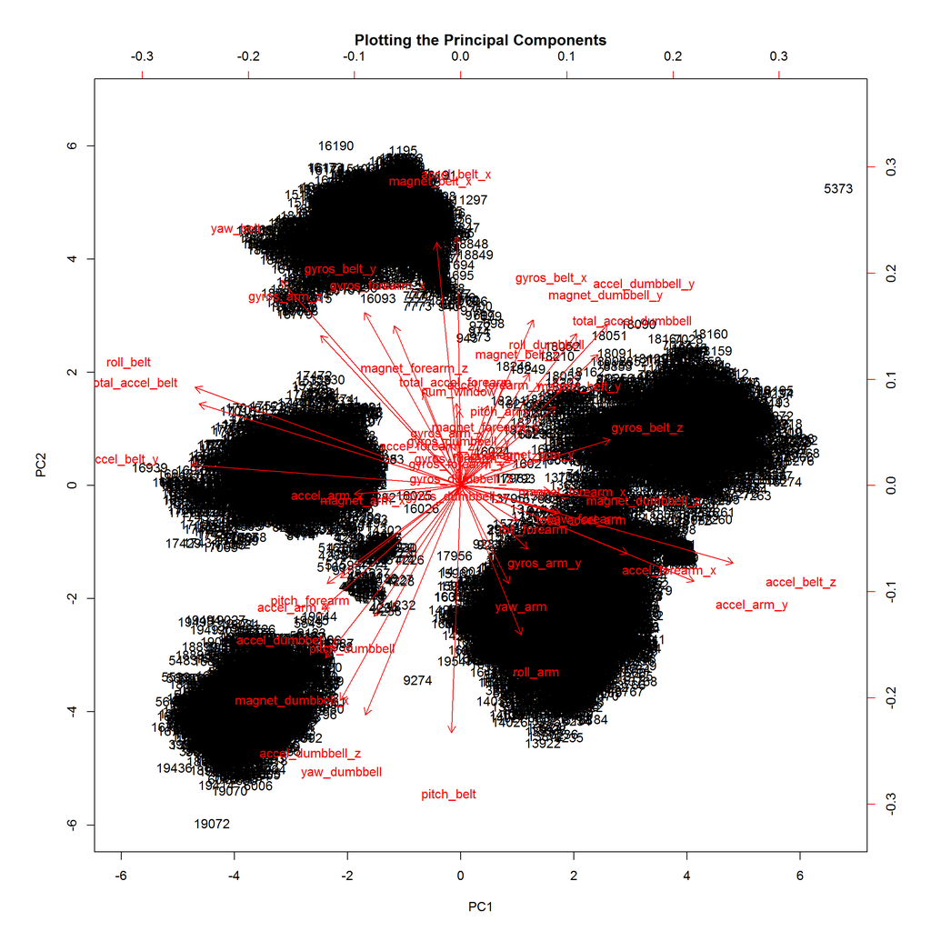

```r
# strip some variables out
y_train <- train[,57]
train <- train[,-c(1,2,3,57)]


# find the principal components
pr <- prcomp(train, scale. = T)

#set plotting parametersz
biplot(pr, scale = 0, main="Plotting the Principal Components")
```

We can see several principal components highlighted by the red lines and along with that we can find that, there are 5 clusters that are formed.

Now we plot the graphs showing the variance explained vs the number of components. To get the insights about how many componets are useful for prediction.

```r
par(mfrow=c(1,2))
# extract standard dev and computer variance
std_dev <- pr$sdev
pr_var <- std_dev^2

print(pr_var[1:10])
```

```
##  [1] 8.357598 8.138721 4.662655 4.185845 3.667275 3.031224 2.256040
##  [8] 2.068248 1.723622 1.512150
```

```r
# compute the variance explained
pr_varex <- pr_var/sum(pr_var)

print(pr_varex[1:10])
```

```
##  [1] 0.15769052 0.15356077 0.08797463 0.07897820 0.06919386 0.05719291
##  [7] 0.04256679 0.03902354 0.03252117 0.02853114
```

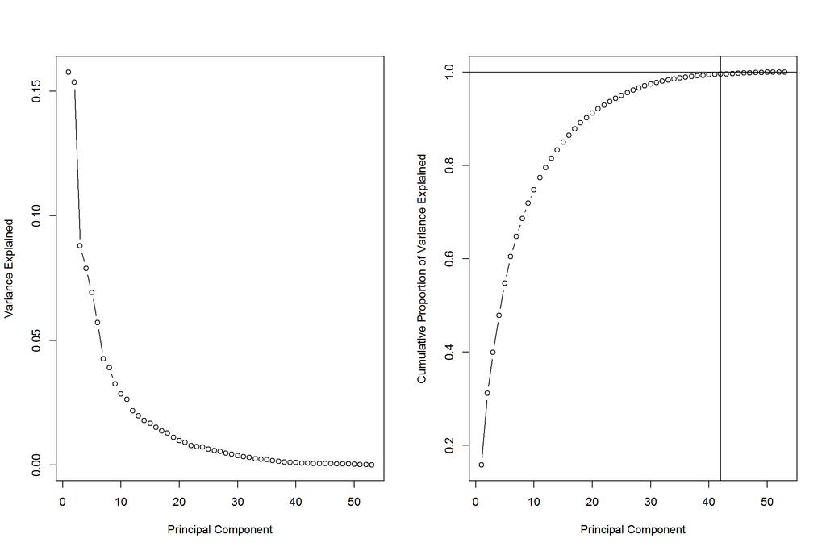

```r
# Plot Principal components vs Variance Explained
plot(pr_varex, xlab = "Principal Component",
                ylab = "Variance Explained",
                  type = "b")

# Plot Cumulative proportion of var explained vs. Principal components
plot(cumsum(pr_varex), xlab = "Principal Component",
                ylab = "Cumulative Proportion of Variance Explained",
                  type = "b")
# Poiniting to 42 as the best principal no of components
abline(h = 1)
abline(v = 42)
```

```r
# Commenmts on Principal components
```

From the above figure we can conclude that, around 40 components cover the whole variance in the data set remaining components do not add any significant accuracy towards the prediction.

## Setting Parallel execution Environment

To speedup the execution of the models we set up a parallel environment.

```r
cluster <- makeCluster(detectCores() - 1) # convention to leave 1 core for OS
registerDoParallel(cluster)
```

## Fitting a Decision Tree

```r
dim(train1)
```

```
## [1] 19622    54
```

```r
dim(train)
```

```
## [1] 17662    53
```

```r
dim(test1)
```

```
## [1] 20 54
```

```r
dim(test)
```

```
## [1] 1960   57
```

```r
train = cbind(train, classe = y_train)
test <- test[,-c(1:3)]

rpart.mod <- rpart(classe~., data = train, method = "class")

rpart.pred <- predict(rpart.mod, test)
rpart.pred <- apply(X = rpart.pred, MARGIN = 1, FUN = function(x) {which.max(x)})
rpart.pred <- as.factor(rpart.pred)
levels(rpart.pred) <- c("A", "B", "C", "D", "E")
rpart.pred <- unname(rpart.pred)

print(confusionMatrix(rpart.pred, test$classe))
```

```
## Confusion Matrix and Statistics
##
##           Reference
## Prediction   A   B   C   D   E
##          A 497  84  10  37  26
##          B  13 185  10   6  22
##          C   6  28 292  44  28
##          D  30  46  12 217  37
##          E  12  36  18  17 247
##
## Overall Statistics
##
##                Accuracy : 0.7337
##                  95% CI : (0.7135, 0.7531)
##     No Information Rate : 0.2847
##     P-Value [Acc > NIR] : < 2.2e-16
##
##                   Kappa : 0.6615
##  Mcnemar's Test P-Value : < 2.2e-16
##
## Statistics by Class:
##
##                      Class: A Class: B Class: C Class: D Class: E
## Sensitivity            0.8907  0.48813   0.8538   0.6760   0.6861
## Specificity            0.8880  0.96774   0.9345   0.9237   0.9481
## Pos Pred Value         0.7599  0.78390   0.7337   0.6345   0.7485
## Neg Pred Value         0.9533  0.88747   0.9680   0.9357   0.9307
## Prevalence             0.2847  0.19337   0.1745   0.1638   0.1837
## Detection Rate         0.2536  0.09439   0.1490   0.1107   0.1260
## Detection Prevalence   0.3337  0.12041   0.2031   0.1745   0.1684
## Balanced Accuracy      0.8893  0.72793   0.8941   0.7999   0.8171
```

The performance of the decision tree on the test or hold out data set is not that greatly impressive. That is why, we go for other models. We do not predict on the testing set with this model as it poorly performs on the hold out set.

## Random Forest Performance on Hold out set

Building random forest on the hold out set. Here, first we check the performance of RF on our hold out set. If it is satisfactory, we proceed furthur to predict using the holdout set.

```r
# Setting cross validation control
fitControl <- trainControl(method = "cv",
                           number = 2,
                           allowParallel = TRUE)
```

```r
# Training the RF of training set
mod.fit <- caret::train(classe~., data = train, method = 'rf', trControl = fitControl)
print(mod.fit$results)
```

```
##   mtry  Accuracy     Kappa   AccuracySD     KappaSD
## 1    2 0.9895255 0.9867491 0.0016814905 0.002126778
## 2   27 0.9951308 0.9938406 0.0009608517 0.001215690
## 3   53 0.9916204 0.9894004 0.0022419873 0.002835017
```

```r
test.pred <- predict(mod.fit, newdata = test)
print(confusionMatrix(test.pred, reference = test$classe))
```

```
## Confusion Matrix and Statistics
##
##           Reference
## Prediction   A   B   C   D   E
##          A 558   0   0   0   0
##          B   0 379   0   0   0
##          C   0   0 342   2   0
##          D   0   0   0 318   1
##          E   0   0   0   1 359
##
## Overall Statistics
##
##                Accuracy : 0.998
##                  95% CI : (0.9948, 0.9994)
##     No Information Rate : 0.2847
##     P-Value [Acc > NIR] : < 2.2e-16
##
##                   Kappa : 0.9974
##  Mcnemar's Test P-Value : NA
##
## Statistics by Class:
##
##                      Class: A Class: B Class: C Class: D Class: E
## Sensitivity            1.0000   1.0000   1.0000   0.9907   0.9972
## Specificity            1.0000   1.0000   0.9988   0.9994   0.9994
## Pos Pred Value         1.0000   1.0000   0.9942   0.9969   0.9972
## Neg Pred Value         1.0000   1.0000   1.0000   0.9982   0.9994
## Prevalence             0.2847   0.1934   0.1745   0.1638   0.1837
## Detection Rate         0.2847   0.1934   0.1745   0.1622   0.1832
## Detection Prevalence   0.2847   0.1934   0.1755   0.1628   0.1837
## Balanced Accuracy      1.0000   1.0000   0.9994   0.9950   0.9983
```

```r
model.fit <- caret::train(classe~., data = train1, method = "rf", trControl = fitControl)
print(model.fit)
```

```
## Random Forest
##
## 19622 samples
##    53 predictor
##     5 classes: 'A', 'B', 'C', 'D', 'E'
##
## No pre-processing
## Resampling: Cross-Validated (2 fold)
## Summary of sample sizes: 9811, 9811
## Resampling results across tuning parameters:
##
##   mtry  Accuracy   Kappa
##    2    0.9926613  0.9907167
##   27    0.9965345  0.9956164
##   53    0.9932219  0.9914259
##
## Accuracy was used to select the optimal model using  the largest value.
## The final value used for the model was mtry = 27.
```

```r
names(test1)[54] <- "classe"
mod.pred <- predict(model.fit, newdata = test1)
print(mod.pred)
```

```
##  [1] B A B A A E D B A A B C B A E E A B B B
## Levels: A B C D E
```

These are the predictions on the testing set.

## GBM

[output not shown]

```r
gbm.fit <- caret::train(classe~., data = train1, method="gbm", verbose = FALSE)
print(confusionMatrix(test.pred, reference = test$classe))
```

[output not shown]

```r
gbm.pred <- predict(gbm.fit, newdata = test1)
print(gbm.pred)
```

```
##  [1] B A B A A E D B A A B C B A E E A B B B
## Levels: A B C D E
```

```r
print(mod.pred)
```

```
##  [1] B A B A A E D B A A B C B A E E A B B B
## Levels: A B C D E
```

## Conclusion

```r
# Stop the cluster
stopCluster(cluster)
registerDoSEQ()
```